# Statistik och dataanalys I

F2: Att hantera och beskriva data

Valentin Zulj

## Kursens syfte

Det här är en praktiskt användbar kurs som lär ut hur du

- utvinner insikter ur datamaterial
- kommunicerar insikter på ett begripligt sätt
- identifierar samband
- bygger enkla statistiska modeller

## Var används det som kursen lär ut?

Det du lär dig här används bland annat av

- data scientists
- business analysts
- statistiker
- ekonomer
- forskare
- … och alla andra som behöver förstå eller förklara de insikter som ett datamaterial ger

## Tips inför kursen

> - Läs igenom kapitlet i boken före föreläsningen
> - Om ett matematiken ser svårt ut: börja med att titta på notationen!
>   **Exempel:** För att förstå innebörden av
>   $$\bar x = \cfrac{\sum_{i=1}^n x_i}{n},$$
>   måste du först förstå vad $\bar x$ och $n$ står för, och vad $\sum_{i=1}^n x_i$ betyder.
> - Om du fastnar och inte hittar svar i boken, fråga!
> - Skjut inte upp pluggandet, utan börja direkt!

# Statistik och data

## Två typer av statistik

**Deskriptiv statistik:** Beskriv din data på ett meningsfullt sätt

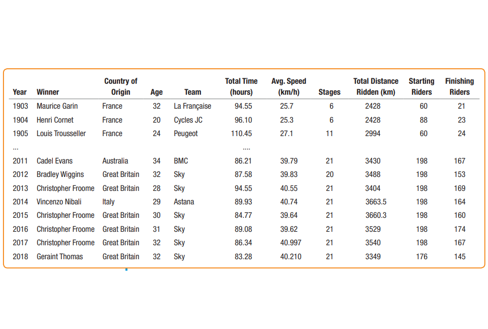

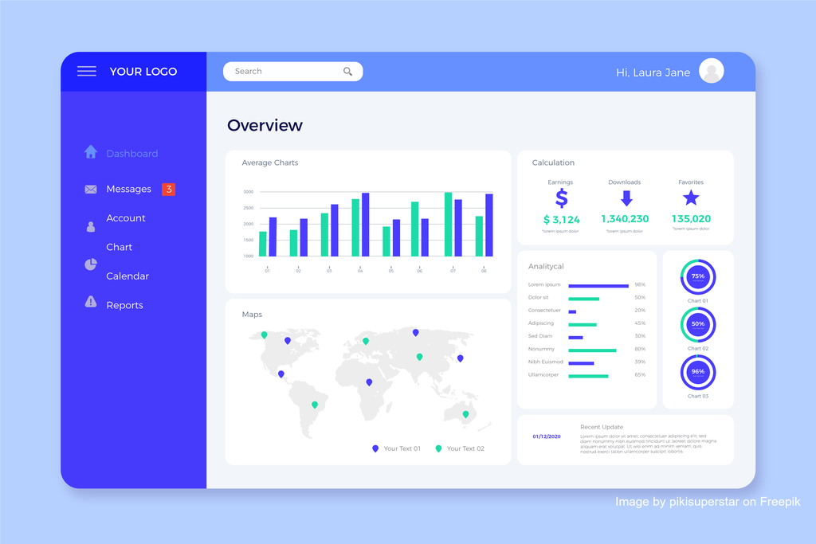

**Inferens:** Dra slutsatser om världen utanför

[figure not shown]

[figure not shown]

## Allting börjar med data

Data är allt som vi kan observera och spara på ett eller annat sätt. De kan vara strukturerade…

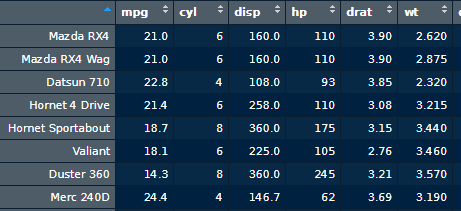

… eller ostrukturerade

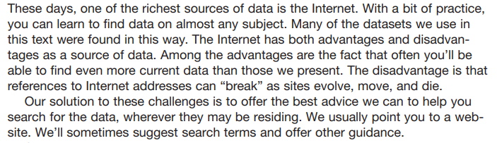

## Dataset, observationer och variabler

Inom statistikämnet brukar en tabell som denna kallas för ett **dataset**

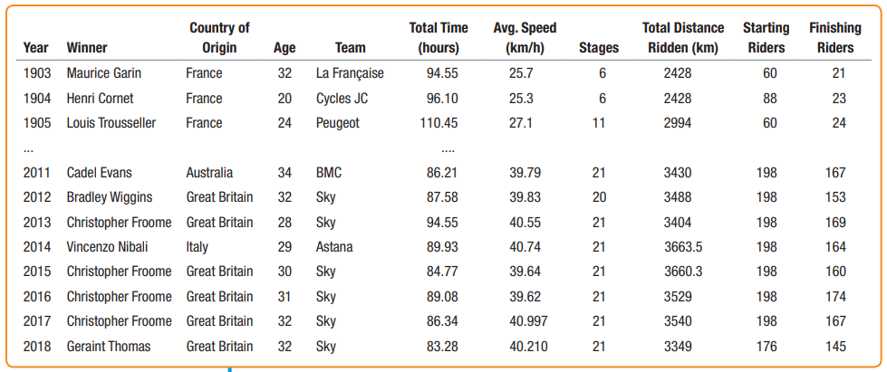

## Dataset, observationer och variabler

Inom statistikämnet brukar en tabell som denna kallas för ett **dataset**

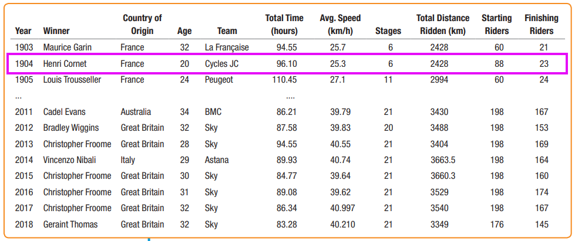

- Varje rad är en observation.

## Dataset, observationer och variabler

Inom statistikämnet brukar en tabell som denna kallas för ett **dataset**

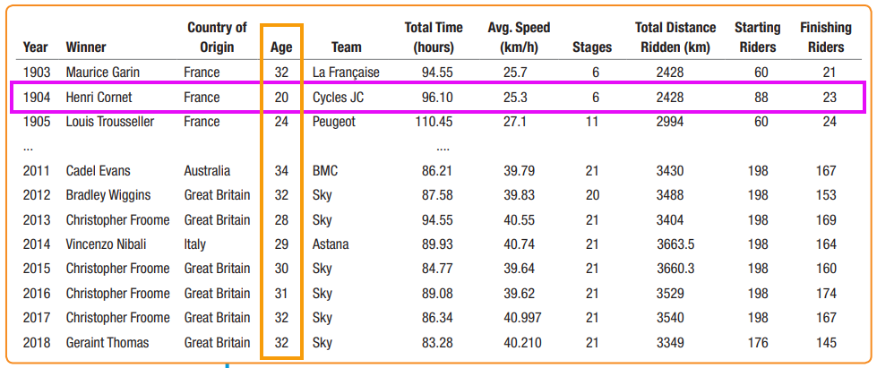

- Varje rad är en observation.
- Varje kolumn är en variabel.

## Glöm inte att fråga varifrån datamaterialet kommer

- Vi är också intresserade av vad som inom statistikämnet brukar kallas **metadata**. Metadata är information **om** vårt datamaterial.
  - *Vem* har samlat in datamaterialet
  - *Hur* är datamaterialet insamlat?
  - *När* är materialet insamlat?
  - Vad betyder variabelnamnen?
  - Hur är variablerna *kodade*?
- Metadata påverkar ofta **trovärdighet** och **användbarhet**

## Olika typer av variabler

- Vårt dataset innehåller två typer av variabler:
  - **Kategoriska** variabler
  - **Numeriska** variabler

## Numeriska variabler

- Har en enhet (meter, kg, kronor, grader celcius, …)
- Har storlekar som kan jämföras (2 kg > 1.5 kg)

## Kategoriska variabler

- Kan användas för att gruppera observationerna
- Ofta i form av text, men kan vara i form av tal
- En numerisk variabel kan göras till en kategorisk variabel

## Andra typer av variabler

- **Ordinala variabler** kan rangordnas (till skillnad från kategoriska variabler), men har ingen enhet (till skillnad från numeriska variabler)
  - **Exempel:** Hur nöjd på en femgradig skala är du med ett köp?

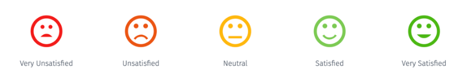

- **ID-variabler** har ett unikt värde för varje observation, t.ex. personnummer i data över individer, eller årtal i data över år

# Att sammanfatta kategoriska variabler

## Kategoriska variabler – hur kan de beskrivas?

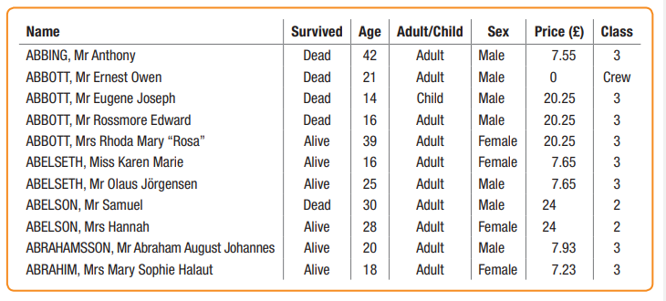

- Vi har ett klassiskt dataset om passagerare och besättning på Titanic
- Det är svårt att få en bra **överblick** med hjälp av tabellen ovan
- Vi vet att det fanns **2208** personer ombord när skeppet sjönk, men
  - Kan vi få en bra bild av antalet passagerare i varje klass?
  - Kan vi få en bild av hur överlevnad skiljer sig mellan klasser, ålder, osv?

## Kategoriska variabler – hur kan de beskrivas?

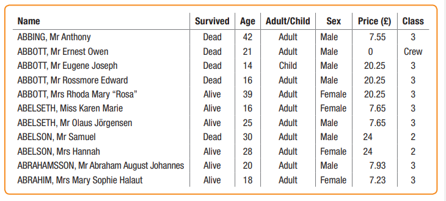

- Vi vill sammanfatta datamaterialet, och göra det överskådligt
- Vi vill t.ex. kunna få en sammanfattning till en rapport på jobbet, eller till en uppsats/inlämning på universitetet – hur kan vi göra det?
- Tabeller och figurer!

## Frekvenstabeller

- En **frekvenstabell** redovisar antalet observationer i varje kategori
- En **relativ frekvenstabell** visar andel (i procent) istället för antal
- Summan av andelar i den relativa frekvenstabellen ska bli 100%  
  ($14.67 \% + 12.91 \% + 32.16 \% + 40.26 \% = 100 \%$)

## Frekvenstabeller

- Andelen i procent som tillhör grupp $a$ räknas ut med formeln
  $$p_a = \cfrac{n_a}{n} \cdot 100$$
- **Notation:**
  - $p_a$ står för andelen i procent som tillhör grupp $a$
  - $n_a$ står för antalet observationer som tillhör grupp $a$
  - $n$ står för det totala antalet observationer i datamaterialet

## Frekvenstabeller

**Exempel:** Andelen som tillhörde besättningen var
$$p_{\text{crew}}
= \cfrac{n_{\text{crew}}}{n} \cdot 100
= \cfrac{889}{2208} \cdot 100 = 40.26 \%,$$
där vi använt att $n = 324+285+710+889$

## Grafiska beskrivningar

- Vi kan beskriva en variabel lite mer pedagogiskt med ett diagram
- Att rita diagram har flera fördelar
  - Vi får en snabbare och tydligare bild av en fördelning
  - Vi kan se samband som är svåra att se i en tabell
- För **en kategorisk variabel** kan vi använda
  - **Stapeldiagram** (*bar plot*), till höger
  - **Pajdiagram** (*pie chart*), till vänster

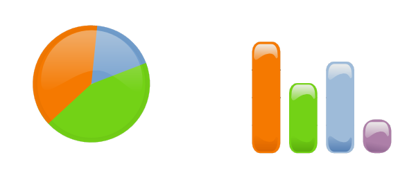

## Stapeldiagram (bar plot)

- Ett stapeldiagram kan vara **baserat på en frekvenstabell**, om staplarnas höjd anger **antalet** observationer som tillhör en viss grupp
- Ett stapeldiagram kan också vara **baserat på en relativ frekvenstabell**, om staplarnas höjd anger **andelen** av observationerna som tillhör en viss grupp

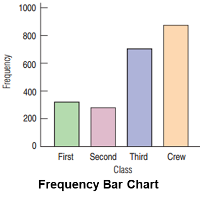

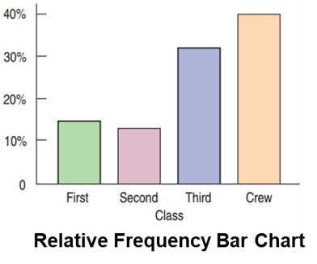

## Pajdiagram (pie chart)

- Ett pajdiagram (även kallat cirkeldiagram)
  - fyller samma funktion som ett stapeldiagram
  - ger en snabb bild av hur stor andel varje grupp utgör
  - visar tydligt när andelar är ungefär 1/2 eller 1/4
- Om det är ett hål i mitten kallas det för ett **munkdiagram** (*donut chart*)

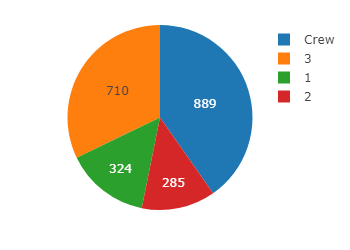

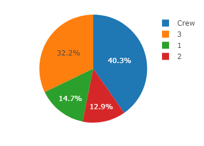

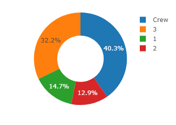

## Stapeldiagram eller pajdiagram?

- Pajdiagram kan vara bättre om publiken har mindre erfarenhet av statistik, medan stapeldiagram brukar föredras av tekniskt kunnig publik
- I ett stapeldiagram är det lättare att se vilken grupp som är större, särskilt om staplarna står i storleksordning

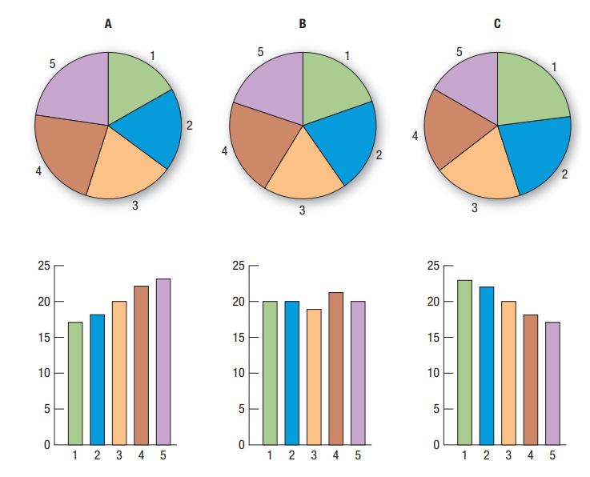

## Areaprincipen

**Fråga:** Jämför den största soptunnan med den minsta? Hur många gånger större skulle du säga att den största soptunnan är?

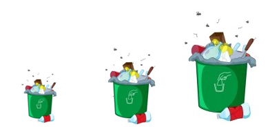

## Areaprincipen

- Vi tenderar att lägga vikt vid staplarnas **area** när vi läser av ett diagram
- Arean bör så vara proprtionell mot den storlek som stapeln representerar
- Detta kallas för **areaprincipen**
- I figuren till vänster ser vi på y-axeln att den största soptupnnan är ungefär **dubbelt** så hög som den minsta, men dess area är **fyra gånger så stor**
- Stapeldiagrammet till höger ger är en mer rättvis representation

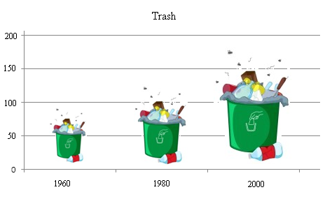

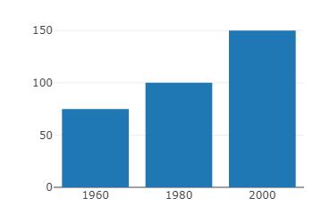

## Areaprincipen

- Ibland bryter vi mot areaprincipen genom att kapa y-axeln (så att den inte börjar vid 0)
- De nedre diagrammen ger en mer rättvis bild/jämförelse än de övre

[figure not shown]

[figure not shown]

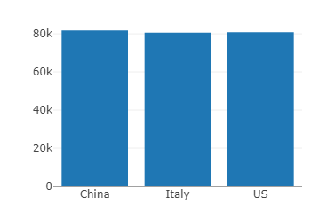

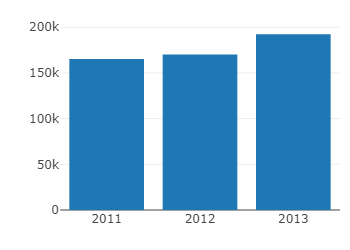